# Course Project 1

# RepData - Peer Assignment 1

## Overview

This analysis looks at the number of steps per day from wearable devices - see README.MD in the github repo for more information

## Load libraries

Libraries needed for analysis

```r
library(plyr)
library(Hmisc)
library(lattice)
setwd("C:/Users/Alex/Documents/KNITR")
```

## Read in CSV data

Data downloaded from https://d396qusza40orc.cloudfront.net/repdata%2Fdata%2Factivity.zip  
Data unzipped and loaded from directory below

```r
dataActivity <- read.csv("activity.csv", header=TRUE)
```

## Histogram of Number of Steps per Day

Work out sum of steps for each date - plot on histogram

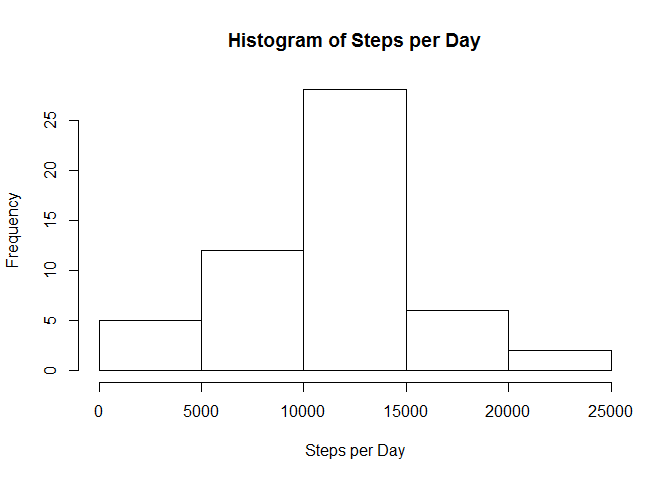

```r
stepsPerDay <- aggregate(steps~date,data=dataActivity, sum)
hist(x=stepsPerDay$steps, xlab="Steps per Day", main="Histogram of Steps per Day")
```

## Calculation of Mean and Median Steps

Calculate the mean, median and total steps per day

```r
meanSteps <- mean(stepsPerDay$steps)
medianSteps <- median(stepsPerDay$steps)
totalSteps <- sum(stepsPerDay$steps)
```

## Plot of Steps per Interval

Calculate and plot the average steps per interval

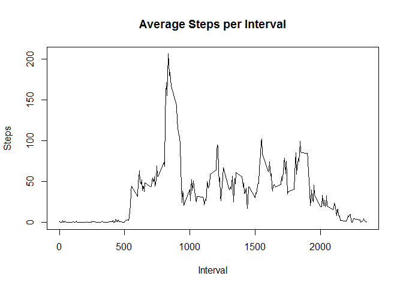

```r
stepsPerInterval <- aggregate(steps~interval,data=dataActivity, FUN=mean)
plot(steps ~ interval, xlab="Interval", ylab="Steps", main="Average Steps per Interval", data=stepsPerInterval, type="l")
```

## Interval that contains the maximum number of steps

Find the interval with the maximum number of steps

```r
intervalMaxSteps <- stepsPerInterval[stepsPerInterval$steps >= max(stepsPerInterval$steps), 1]
```

The interval with the max steps is 835

## Number of NAs

Calculate the number of records with NA in the data

```r
numberOfNAs <- sum(is.na(dataActivity$steps))
```

The number of NAs in the data is 2304

## Impute on NAs - Create new Imputed data set for NAs

Save the mean when there is an NA - use impute function to do this

```r
dataActivityImputed <- dataActivity
dataActivityImputed$stepsImputed <- with(dataActivity,impute(dataActivity$steps, mean))
dataActivityImputed$steps <- dataActivityImputed$stepsImputed
```

## Make new histogram off Imputed data set

calculate and plot the **imputed** steps per day

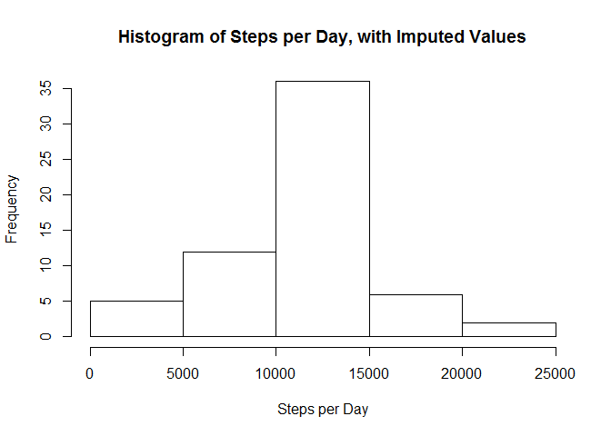

```r
stepsPerDayImputed <- aggregate(steps~date,data=dataActivityImputed, sum)
hist(x=stepsPerDayImputed$steps, xlab="Steps per Day", main="Histogram of Steps per Day, with Imputed Values")
```

Note that this looks very close to previous plot with NAs

## Mean and Median on Imputed data set - Comparison

Calculate the mean, median and total steps

```r
meanStepsImputed <- mean(stepsPerDayImputed$steps)
medianStepsImputed <- median(stepsPerDayImputed$steps)
totalStepsImputed <- sum(stepsPerDayImputed$steps)
```

## Comparing the results

# Add Weekday and Weekend Indicators

Add weekday, weekend indicators

```r
dataActivityImputed$Weekday <- weekdays(as.Date(dataActivityImputed$date))
dataActivityImputed$IsWeekend <- grepl('Saturday|Sunday', dataActivityImputed$Weekday)
dataActivityImputed$IsWeekday <- !grepl('Saturday|Sunday', dataActivityImputed$Weekday)
dataActivityImputed$WeekdayStatus <- ifelse(dataActivityImputed$IsWeekday==TRUE,"weekday","weekend")
```

# Panel plot - Weekday Steps vs Weekend Steps

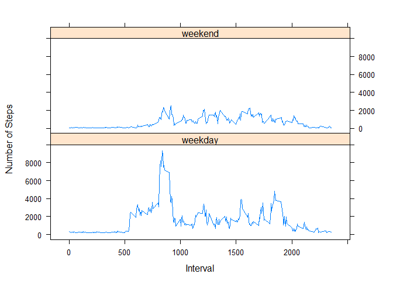

```r
stepsPerIntervalImputed <- aggregate(steps ~ interval + WeekdayStatus,data=dataActivityImputed, FUN=sum)
xyplot(steps~interval|factor(WeekdayStatus),type="l",layout=c(1,2), xlab="Interval",ylab="Number of Steps", data=stepsPerIntervalImputed)
```